# Spatial smoothing

Peter Ralph

8 March 2021 – Advanced Biological Statistics

# Biketown, again

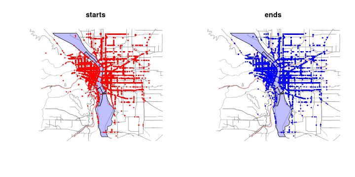

```r
layout(t(1:2))
setup_map(main='starts'); points(bt_start, pch=20, cex=0.5, col='red')
setup_map(main='ends'); points(bt_end, pch=20, cex=0.5, col='blue')
```

## Goals:

Visualize:

1. Starting and ending locations of trips.
2. Net flux of bikes by area (e.g., places where more trips start than end).
3. Distance of trips depending on start and end location.

## What is mean local trip length?

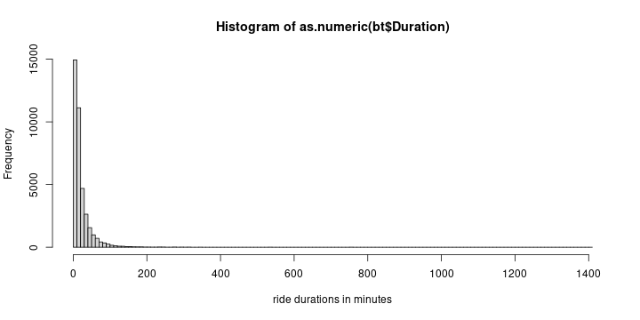

```r
bt$Duration <- as.numeric(as.difftime(bt$Duration, format="%X"))
hist(as.numeric(bt$Duration), breaks=200, xlab='ride durations in minutes')
```

# Smoothing

## The general idea:

Response equals smooth plus noise:
$$y_i \approx f(x_i),$$
where

- $y_i$: response of $i^\text{th}$ observation
- $x_i$: location in space of $i^\text{th}$ observation
- $f( )$: a “smooth” function

*To be determined:* What’s “smooth”? What’s “plus noise”?

## Our old friend, loess

```r
ytsm <- loess(y ~ t, data=yt, span=0.1)
yt$smoothed <- predict(ytsm, newdata=yt)
```

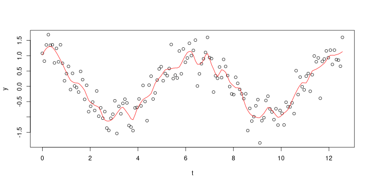

## … applied to these data:

```r
lo_dur <- loess(Duration ~ Start_Latitude * Start_Longitude, data=bt, span=0.3)
pred_lats <- seq(min(bt$Start_Latitude), max(bt$Start_Latitude), length.out=101)
pred_lons <- seq(min(bt$Start_Longitude), max(bt$Start_Longitude), length.out=101)
pred_locs <- expand.grid(Start_Latitude=pred_lats,
                         Start_Longitude=pred_lons)
pred_duration <- predict(lo_dur, newdata=pred_locs)
```

## … loess!?!?!

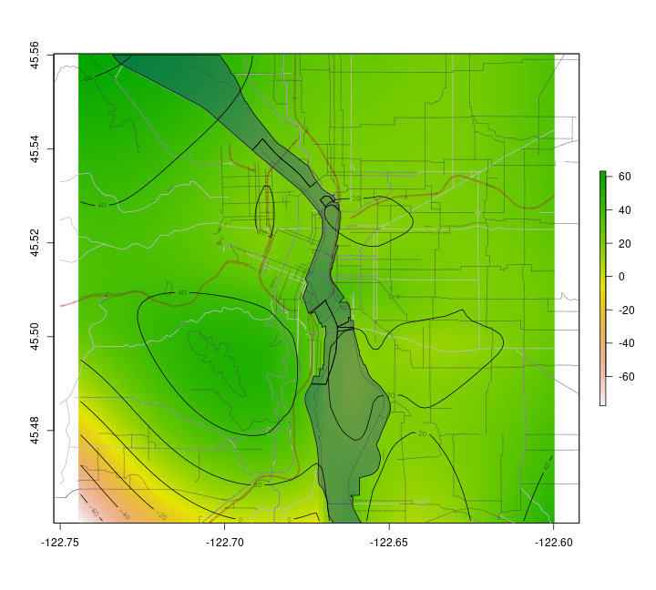

# Gaussian processes for smoothing

Response equals smooth plus noise:
$$y_i = f(x_i) + \epsilon_i,$$
where

- $y_i$: response of $i^\text{th}$ observation
- $x_i$: location in space of $i^\text{th}$ observation
- $\epsilon_i \sim \Normal(0, \sigma^2_\epsilon)$: observation noise

and $f(x)$ is spatially autocorrelated:

$$\begin{aligned}
f(x_i) &\sim \MVN(\mu, \Sigma) \\
\cov[f(x_i), f(x_j)] &= \rho(\|x_i - x_j\|) .
\end{aligned}$$

## Also known as: Kriging

```
> help(Krig, package="fields")
Krig                  package:fields                   R Documentation

Kriging surface estimate

Description:

     Fits a surface to irregularly spaced data. The Kriging model
     assumes that the unknown function is a realization of a Gaussian
     random spatial processes. The assumed model is additive Y = P(x) +
     Z(X) + e, where P is a low order polynomial and Z is a mean zero,
     Gaussian stochastic process with a covariance that is unknown up
     to a scale constant. The main advantages of this function are the
     flexibility in specifying the covariance as an R language function
     and also the supporting functions plot, predict, predictSE,
     surface for subsequent analysis. Krig also supports a correlation
     model where the mean and marginal variances are supplied.

Usage:

     Krig(x, Y, cov.function = "stationary.cov", lambda = NA, df
                      = NA, GCV = FALSE, Z = NULL, cost = 1, knots = NA,
                      weights = NULL, m = 2, nstep.cv = 200, scale.type =
                      "user", x.center = rep(0, ncol(x)), x.scale = rep(1,
                      ncol(x)), rho = NA, sigma2 = NA, method = "REML",
                      verbose = FALSE, mean.obj = NA, sd.obj = NA,
                      null.function = "Krig.null.function", wght.function =
                      NULL, offset = 0, na.rm = TRUE, cov.args = NULL,
                      chol.args = NULL, null.args = NULL, wght.args = NULL,
                      W = NULL, give.warnings = TRUE, ...)
```

```r
krig_dur <- fields::Krig(x=cbind(bt$Start_Latitude, bt$Start_Longitude), Y=bt$Duration)
pred_krig <- matrix(predict(krig_dur, x=pred_locs), nrow=length(pred_lats))
```

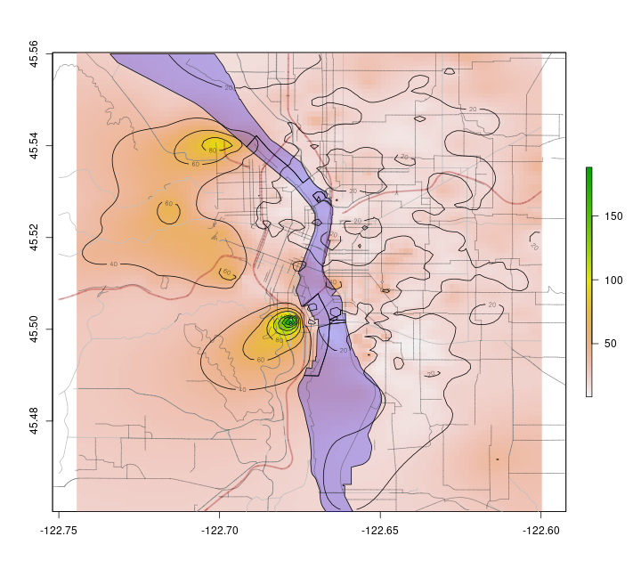

# More familiar tools

## `gp( )`

In brms, we can use `gp( )` to add a “Gaussian process” predictor:

```r
brsm <- brm(y ~ gp(t), data=subset(yt, t > 5 & t < 8), control=list(adapt_delta=0.9))
pred_df <- data.frame(t=seq(4, 9, length.out=101))
pred_df <- cbind(pred_df, predict(brsm, newdata=pred_df))
```

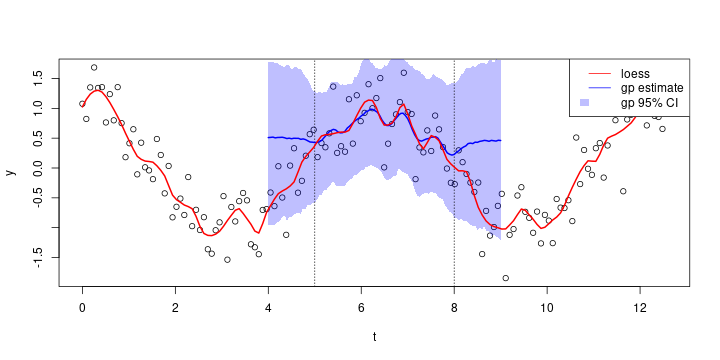

## Note: more predictors

A bivariate predictor is specified by:

```
    y ~ gp(x1, x2)
```

*Question:* what’s the difference to

```
    y ~ gp(x1) + gp(x2)
```

?

## However…

Gaussian processes don’t scale well. This would take **forever**:

```
brsm <- brm(y ~ gp(t), data=yt)
yt$brms_gp <- predict(ytsm, newdata=yt)
```

*Why?* With $n$ observations, the covariance matrix has $n^2$ entries. Fitting the MVN requires *inverting* it.

# Splines

## You might already know about splines:

[Bézier curves](https://en.wikipedia.org/wiki/B%C3%A9zier_curve) are piecewise polynomial, i.e., splines:

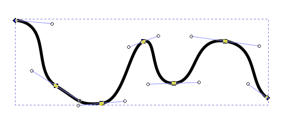

## Smoothing with splines:

Response equals smooth plus noise:
$$y_i = f(x_i) + \epsilon_i,$$
where

- $y_i$: response of $i^\text{th}$ observation
- $x_i$: location in space of $i^\text{th}$ observation
- $\epsilon_i \sim \Normal(0, \sigma^2_\epsilon)$: observation noise

and $f(x)$ is a $k$-th order *spline* with *knots* $u_1, \ldots, u_m$:
$$\begin{aligned}
f(x) &= a_{j0} + a_{j1} x + a_{j2} x^2 + \cdots + a_{jk} x^k \\
\text{for} &\qquad u_j \le x \le u_{j+1} .
\end{aligned}$$
and ‘smooth’ at the knots.

## Fitting a spline model:

Using `brms`, this is as easy as using `s( )` as a predictor:

```r
brm_spline <- brm(y ~ s(t), data=yt,
                  prior=c(set_prior("exponential(1000)", class='sigma')))
s_pred_df <- data.frame(t=seq(0, max(yt$t), length.out=501))
```

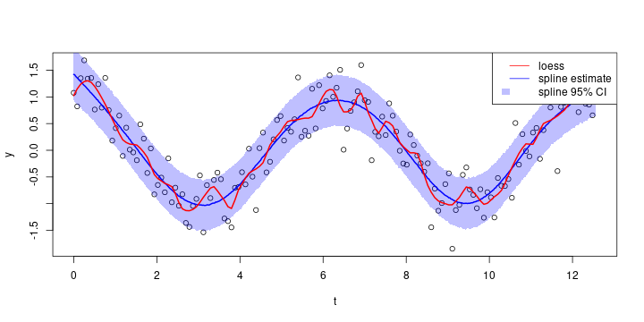

## Applied to biketown

```r
downtown <- subset(bt, Start_Latitude > 45.51 & Start_Latitude < 45.53
                       & Start_Longitude > -122.69 & Start_Longitude < -122.67
                       & (rbinom(nrow(bt), size=1, prob=0.1) == 1))
s_dur <- brm(Duration ~ t2(Start_Latitude, Start_Longitude),
             data=downtown)
```

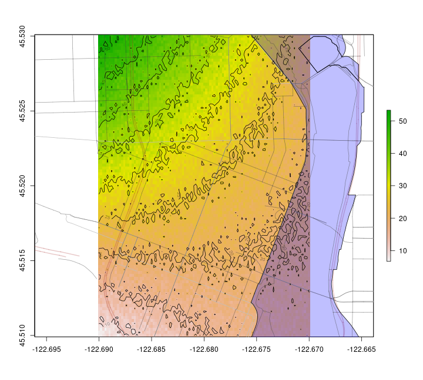

## Conclusion

Built-in smoothing with `~ gp( )` and `~ s( )` and `~ t2( )` in brms is very promising.

But, it’s not magical (yet).

# More with splines:

Recall that a Generalized Linear Model (GLM) has 1. a *family* describing the distribution of the response, $Y$ 2. a *linear predictor*
$$\begin{aligned}
X \beta = \beta_0 + \beta_1 X_1 + \cdots + \beta_n X_n
\end{aligned}$$
3. a *link function* connecting the two:
$$\begin{aligned}
h(\E[Y]) = X\beta .
\end{aligned}$$

## “Linear” $\to$ “Additive”

A Generalized *Additive* Model (GAM) replaces the linear predictor with
$$\begin{aligned}
\beta_0 + f_1(X_1) + \cdots + f_n(X_n),
\end{aligned}$$
where each $f_i( )$ is some *smooth function*, e.g., a spline.

// reveal.js plugins